# Curso 2 R Programming

## Datatypes

Los dos puntos se usan para declarar secuencias:

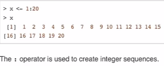

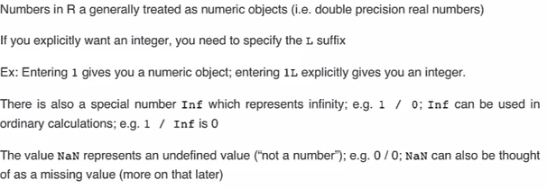

Los objetos tienen atributos accesibles por la función attribute(x), tipo, nombre, etc..

**Vectores** son siempre del mismo tipo, estos son los posibles tipos:

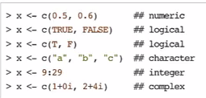

Si se mezclan tipos se hace coercion, y se le asigna el tipo más aproximado a un vector, por ejemplo si hay un entero y un carácter, se convierte todo a caracter.

Se puede hacer coercion explícita con as.

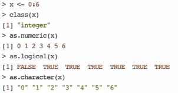

Las operaciones vectorizadas nos evitan tener que implementar bucles para operar:

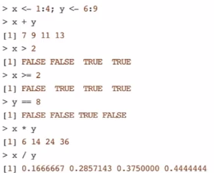

Cuando operas con vector con un número simple operas cada elemento del vector por ese número:

cuando haces c(2,5,1) * 2 + 100, |o que hace realmente es : c(2,5,1) * c(2, 2, 2) + c(100, 100, 100)

Si combinamos un vector numérico con uno literal, si hacemos paste entre ambos vectores se hace coerción del primero, se transforma en literal y adapta su tamaño al de mayor tamaño

paste(LETTERS, 1:4, sep = “-”)

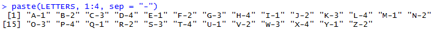

Si hacemos esto

y <- x > 4

Nos devuelve en y un vector del mismo tamñano que x con la evaluación de cada elemento de x de la expresión

y <- x[x>4]

Nos devuelve un vector con los elementos de x que cumplen la expresión.

para acceder a valores concretos del vector

y <- x[c(4,7,10)]

Hay que tener cuidado, porque nada nos impide hacer y[0] que no existe en R o y[400] que tampoco existe en el vector y nos devuelve NA

Si queremos obtener todos menos el elemento en segunda posición, podemos hacerlo con el -

y <- x[c(-2)] ó x[-c(2, 10)]

Se puede poner nombre a los elementos:

vect <- c(foo = 11, bar = 2, norf = NA)

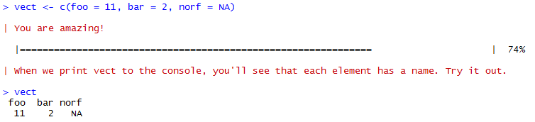

se pueden poner nombres a posteriori también

names(vect2) <- c(“foo”, “bar”, “norf”)

Las **listas** permiten tener objetos de distinto tipo:

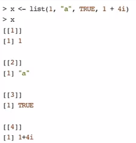

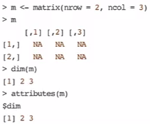

Si llenas una matriz con valores consecutivos irá rellenando la matriz de arriba a abajo y de izquierda a derecha por toda la matriz.

Además, un vector se puede convertir en matriz añadiendo el atributo dim()

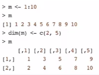

La última manera es juntando vectores que deben ser del mismo tamaño, o bien en columnas cbind o bien en filas rbind

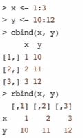

Se puede operar sobre las matrices de la misma manera que con los vectores, pero usando la notación correcta (la tercera):

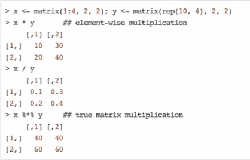

Para poner nombre a las columnas de una matriz o dataframe, hay que crear primero un vector con todos los nombres: cnames <- c(“age”, “weight”, “bp”, “rating”, “test”)

colnames(matrix) <- cnames

y lo mismo para las filas:

patients <- c(“Bill”,“Gina”,“Kelly”,“Sean”) rownames(matrix) <- patients

my_data2 <- matrix (1:20,4,5)

Los **Factores** son datos categorizados, que pueden ser ordenables o no. Se puede decir que un factor es vector de enteros en el que cada entero tiene una etiqueta, de manera que podamos usar la etiqueta en lugar del número entero (ejemplo usar masculino/femenino en lugar de 1/2).

De los vectores que están factorizados se pueden sacar directamente tablas sumarizadas con el conteo de cada valor. unclass te dice qué valor entero tiene el factor.

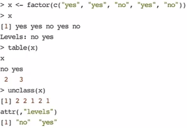

Para dar un orden a los factores se utiliza el argumento levels(), aquí por ejemplo si no lo usáramos el primer nivel sería “No” por orden alfabético

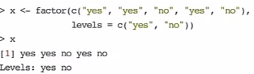

**Valores nulos** pueden ser NA (vacío) y NaN (Not a Number). NaN es un subconjunto de NA

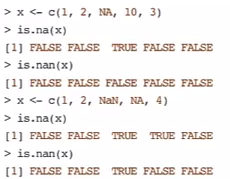

Para eliminar valores nulos, la función complete.cases nos da las posiciones que tienen valores no nulos:

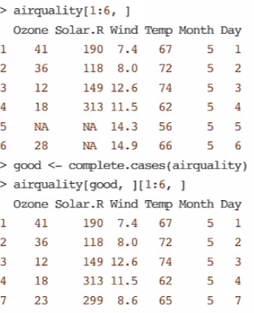

**DATA FRAMES**

Se usa para guardar datos tabulares. Pueden tener tipos distintos. Ademàs tienen un atributo especial que es row.names, en este caso como no hemos especificado automáticamente son enteros.

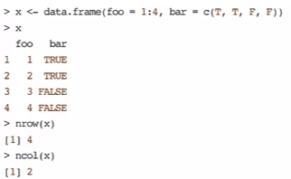

En realidad, todos los objetos en R tienen el atributo nombre, no sólo los dataframes, vectores y matrices también.

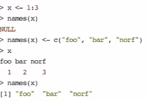

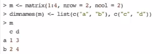

**Subconjuntos**

Funcionalidad para tomar subconjuntos de datos de una estructura. A continuación se ve cómo extraer elementos de una lista, distinguiendo entre un sólo [ que nos devuelve un objeto del mismo tipo, o [[ que nos devuelve únicamente un elemento.

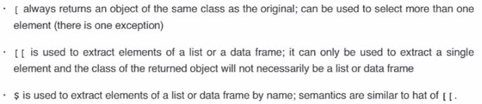

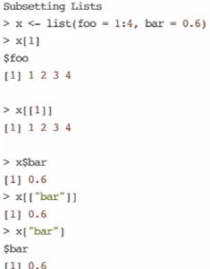

Tambien podemos utilizar coincidencia parcial para recoger los elementos de una estructura, en este ejemplo vemos que con sólo poner ‘a’ ya nos devuelve el elemento que comienza por esa letra

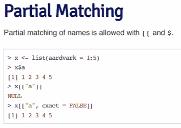

Podemos por tanto usando [ pasar el nombre de una columna de un data frame como parámetro a una función. En este ejemplo la función toma de un directorio todos los archivos csv con el nombre coincidente en el vector id, y calcula la media de la columna pasada como parámetro en pollutant, en este caso los CSV tenían 2 agentes, el sulfato y el nitrato, se podían pasar ambos:

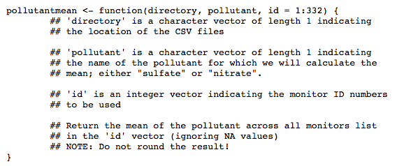

pollutantmean <- function(directory,pollutant,id = 1:332) {

TOTAL <- data.frame()

for (i in 1:length(id)){ TEMP = read.csv(file.path(directory,paste(id[i],“.csv”,sep=“”)) ,header = TRUE) TOTAL = rbind(TOTAL,TEMP)

} mean(TOTAL[,pollutant],na.rm=TRUE) }

A = pollutantmean(“C:/Users/MH026898/OneDrive - Cerner Corporation/Workspaces/courses-master/02_RProgramming/specdata”,“sulfate”,c(“001”,“002”,“003”))

A = 4.278766

**Funciones útiles**

file.path(“folder1”,“folder2”,“file1.csv”) –> Permite acceder al fichero independientemente del sistema operativo, en el caso de linux te devuelve “folder1/folder2/file1.csv”

generar4 números aleatorios del 1 al 10

v <- sample(10,4)

wich(v > 7) nos da los indices de los elementos que su valor sea mayor que 7

any(v>7 ) devuelve true si encuntra alguno mayor que 7

all(v>7) devuelve true si todos son mayor que 7

seq(5, 10, length=30)

generar una secuencia entre 1 y 10 seq(1,10)

generar secuencia con intervalos de 0,5 (el doble de valores)

seq(1,10,by=0.5)

Repetir un valor n veces rep(0, times = 40)

repetir tres valores n veces rep(c(0,1, 2), times = 10)

seq_along(x) -> nos da un vector de igual longitud que X y relleno con una secuencia de 1 a length(x)

range(x) -> devuelve el máximo y el mínimo valor de lo que se le pase

split(airquality,airquality$mounth) –> devuelve una lista de dataframes, cada dataframe correspodiente al mes del dataset inicial.

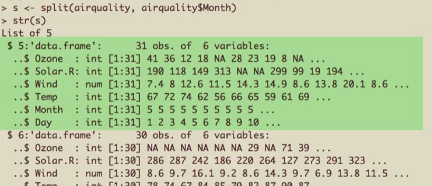